# Exercises

Estad?stica avanzada

Septiembre 2017

# 1 Generar secuencias

Rellenar los vectores siguientes:

v1: 1 2 3

v2: 1 2 3 1 2 3 1 2 3

v3: 0 10 20 30 40 50 60 70 80 90 100

v4: 1000 900 800 700 600 500 400 300 200 100 0

v5: 1 1 1 1 1

```r
v1 <- c(1,2,3)
v1
```

```
## [1] 1 2 3
```

```r
v2 <- rep( v1, 3 )
v2
```

```
## [1] 1 2 3 1 2 3 1 2 3
```

```r
v3<-seq(0, 100, 10)
v3
```

```
##  [1]   0  10  20  30  40  50  60  70  80  90 100
```

```r
v4<-seq(1000, 0, -100)
v4
```

```
##  [1] 1000  900  800  700  600  500  400  300  200  100    0
```

```r
v5<-rep( 1, 5)
v5
```

```
## [1] 1 1 1 1 1
```

# 2 Realizar c?lculos a nivel de vector

1. Cacular la suma, media, rango, m?ximo y m?nimo de un vector de n?meros que contiene valores desde 1,500 hasta 500 step -2.
2. Ordenar el vector en orden creciente
3. Contar cuantos elementos hay en el vector.

```r
v<-seq( 1500, 500, -2)
v
```

```
##   [1] 1500 1498 1496 1494 1492 1490 1488 1486 1484 1482 1480 1478 1476 1474 1472
##  [16] 1470 1468 1466 1464 1462 1460 1458 1456 1454 1452 1450 1448 1446 1444 1442
##  [31] 1440 1438 1436 1434 1432 1430 1428 1426 1424 1422 1420 1418 1416 1414 1412
##  [46] 1410 1408 1406 1404 1402 1400 1398 1396 1394 1392 1390 1388 1386 1384 1382
##  [61] 1380 1378 1376 1374 1372 1370 1368 1366 1364 1362 1360 1358 1356 1354 1352
##  [76] 1350 1348 1346 1344 1342 1340 1338 1336 1334 1332 1330 1328 1326 1324 1322
##  [91] 1320 1318 1316 1314 1312 1310 1308 1306 1304 1302 1300 1298 1296 1294 1292
## [106] 1290 1288 1286 1284 1282 1280 1278 1276 1274 1272 1270 1268 1266 1264 1262
## [121] 1260 1258 1256 1254 1252 1250 1248 1246 1244 1242 1240 1238 1236 1234 1232
## [136] 1230 1228 1226 1224 1222 1220 1218 1216 1214 1212 1210 1208 1206 1204 1202
## [151] 1200 1198 1196 1194 1192 1190 1188 1186 1184 1182 1180 1178 1176 1174 1172
## [166] 1170 1168 1166 1164 1162 1160 1158 1156 1154 1152 1150 1148 1146 1144 1142
## [181] 1140 1138 1136 1134 1132 1130 1128 1126 1124 1122 1120 1118 1116 1114 1112
## [196] 1110 1108 1106 1104 1102 1100 1098 1096 1094 1092 1090 1088 1086 1084 1082
## [211] 1080 1078 1076 1074 1072 1070 1068 1066 1064 1062 1060 1058 1056 1054 1052
```

[output cut: 19 more lines]

```r
sum(v)
```

```
## [1] 501000
```

```r
mean(v)
```

```
## [1] 1000
```

```r
range(v)
```

```
## [1]  500 1500
```

```r
max(v)
```

```
## [1] 1500
```

```r
min(v)
```

```
## [1] 500
```

```r
sort(v)
```

```
##   [1]  500  502  504  506  508  510  512  514  516  518  520  522  524  526  528
##  [16]  530  532  534  536  538  540  542  544  546  548  550  552  554  556  558
##  [31]  560  562  564  566  568  570  572  574  576  578  580  582  584  586  588
##  [46]  590  592  594  596  598  600  602  604  606  608  610  612  614  616  618
##  [61]  620  622  624  626  628  630  632  634  636  638  640  642  644  646  648
##  [76]  650  652  654  656  658  660  662  664  666  668  670  672  674  676  678
##  [91]  680  682  684  686  688  690  692  694  696  698  700  702  704  706  708
## [106]  710  712  714  716  718  720  722  724  726  728  730  732  734  736  738
## [121]  740  742  744  746  748  750  752  754  756  758  760  762  764  766  768
## [136]  770  772  774  776  778  780  782  784  786  788  790  792  794  796  798
## [151]  800  802  804  806  808  810  812  814  816  818  820  822  824  826  828
## [166]  830  832  834  836  838  840  842  844  846  848  850  852  854  856  858
## [181]  860  862  864  866  868  870  872  874  876  878  880  882  884  886  888
## [196]  890  892  894  896  898  900  902  904  906  908  910  912  914  916  918
## [211]  920  922  924  926  928  930  932  934  936  938  940  942  944  946  948
```

[output cut: 19 more lines]

```r
length(v)
```

```
## [1] 501
```

# 3 C?lculos arim?ticos con vectores num?ricos

1. Crear un vector con valores de 1 a 20.
2. Restar 1 a todos los elementos del vector
3. Para cada elemento, calcular su cuadrado

```r
v<-c(1:20)
v
```

```
##  [1]  1  2  3  4  5  6  7  8  9 10 11 12 13 14 15 16 17 18 19 20
```

```r
v-1
```

```
##  [1]  0  1  2  3  4  5  6  7  8  9 10 11 12 13 14 15 16 17 18 19
```

```r
v^2
```

```
##  [1]   1   4   9  16  25  36  49  64  81 100 121 144 169 196 225 256 289 324 361
## [20] 400
```

# 4 C?lculos aritm?ticos con varios vectores num?ricos

1. Crer un vector v1 con valores de 0 a 20 y otro vector v2 con valores de -10 to +10
2. Generar un vector vsum que contiene la suma de los elementos de los dos vectores, posici?n por posici?n.

```r
v1<-c(0:20)
v2<-c(-10:10)
length(v1)
```

```
## [1] 21
```

```r
length(v2)
```

```
## [1] 21
```

```r
vsum <- v1 + v2
vsum
```

```
##  [1] -10  -8  -6  -4  -2   0   2   4   6   8  10  12  14  16  18  20  22  24  26
## [20]  28  30
```

# 5 Vectores num?ricos

Disponemos de un vector “quantity” y un vector de precios “price”:

- quantity: 20 3 4 5 6 7 8 5 2 12
- price: 2 4 5 63 40 21 12 6 7 4

Cada posici?n del vector quantity es la cantidad de productos vendidos. El precio est? guardado en la misma posici?n del vector price. Calcular el precio total de todos los productos.

```r
quantity <- c(20,3,4,5,6,7,8,5,2,12)
price <- c(2,4,5,63,40,21,12,6,7,4)
quantity
```

```
##  [1] 20  3  4  5  6  7  8  5  2 12
```

```r
price
```

```
##  [1]  2  4  5 63 40 21 12  6  7  4
```

```r
total_price<-quantity*price
total_price
```

```
##  [1]  40  12  20 315 240 147  96  30  14  48
```

```r
total_amount<-sum( total_price )
total_amount
```

```
## [1] 962
```

# 6 Vectores num?ricos y l?gicos

Dados los siguientes vectores:

x: 3 4 6 -5 1 3 9 10 -1 0 -4

y: -4 4 6 5 1 3 9 1 -10 5 14

Realizar los c?lculos siguientes:

1. Cu?ntos elementos del vector x son positivos?

   ```r
   x<-c(3,4,6,-5,1,3,9,10,-1,0,-4)
   y<-c(-4,4,6,5,1,3,9,1,-10,5,14)
   #Elements of x greater than 0
   x>0
   ```

   ```
   ##  [1]  TRUE  TRUE  TRUE FALSE  TRUE  TRUE  TRUE  TRUE FALSE FALSE FALSE
   ```

   ```r
   sum(x>0)
   ```

   ```
   ## [1] 7
   ```

   ```r
   length( which(x>0) )
   ```

   ```
   ## [1] 7
   ```

2. Qu? elementos del vector x son mayores que los elementos del vector y (considerando posici?n por posici?n).

   ```r
   #elements where x > y: index, elements, how many
   which( x>y )
   ```

   ```
   ## [1] 1 8 9
   ```

   ```r
   x[ x>y ]
   ```

   ```
   ## [1]  3 10 -1
   ```

   ```r
   length( which(x>y) )
   ```

   ```
   ## [1] 3
   ```

3. Borrar del vector x los elementos que son iguales a los elementos que ocupan la misma posici?n en y.

   ```r
   #Visualization
   paste(x, y)
   ```

   ```
   ##  [1] "3 -4"   "4 4"    "6 6"    "-5 5"   "1 1"    "3 3"    "9 9"    "10 1"
   ##  [9] "-1 -10" "0 5"    "-4 14"
   ```

   ```r
   #elements where x == y
   x==y
   ```

   ```
   ##  [1] FALSE  TRUE  TRUE FALSE  TRUE  TRUE  TRUE FALSE FALSE FALSE FALSE
   ```

   ```r
   which(x==y)
   ```

   ```
   ## [1] 2 3 5 6 7
   ```

   ```r
   x[ !(x==y) ]
   ```

   ```
   ## [1]  3 -5 10 -1  0 -4
   ```

   ```r
   #Modifying x so that only the elements that are different remain
   x<-x[ !(x==y) ]
   x
   ```

   ```
   ## [1]  3 -5 10 -1  0 -4
   ```

# 7 Factors

El siguiente vector pertenece al nivel de estudios de 20 personas:

studies <- c(“n”, “p”, “s”, “p”, “s”, “t”, “o”, “s”, “o” , “p”, “p”,“s”, “s”,“t”,“p”,“t”,“o”,“n”,“p”,“o”)

1. Calcular cu?ntos tipos de educaci?n hay.
2. Para hacerlo m?s comprensible, cambiar el valor de los niveles a los siguientes:

   n : none

   p : primary

   s : secondary

   t : tertiary

   o : other
3. Mostrar cuantas personas hay para cada tipo de educaci?n.

```r
studies <- factor(c("n", "p", "s", "p", "s", "t", "o", "s", "o" , "p", "p","s", "s","t","p","t","o","n","p","o"))
length( studies)
```

```
## [1] 20
```

```r
#types of education
levels( studies )
```

```
## [1] "n" "o" "p" "s" "t"
```

```r
#changing names
levels( studies ) <- c("none", "other", "primary", "secondary", "tertiary")
studies
```

```
##  [1] none      primary   secondary primary   secondary tertiary  other
##  [8] secondary other     primary   primary   secondary secondary tertiary
## [15] primary   tertiary  other     none      primary   other
## Levels: none other primary secondary tertiary
```

```r
table( studies )
```

```
## studies
##      none     other   primary secondary  tertiary
##         2         4         6         5         3
```

# 8 Matrices

1. Generar una matriz de 10 filas y 6 columnas, cuyos valores de cada columna son los m?ltiples del ?ndice de la columna, tal como sigue:

   [1,] 1 2 3 4 5 6

   [2,] 2 4 6 8 10 12

   [3,] 3 6 9 12 15 18

   [4,] 4 8 12 16 20 24

   [5,] 5 10 15 20 25 30

   [6,] 6 12 18 24 30 36

   [7,] 7 14 21 28 35 42

   [8,] 8 16 24 32 40 48

   [9,] 9 18 27 36 45 54

   [10,] 10 20 30 40 50 60
2. Etiquetar cada columna como: M1, M2, … M6
3. Borrar las dos ?ltimas filas.
4. Cambiar el signo de los valores de la columna 3.
5. Mostrar el contenido de la columna 2

```r
#Creating
v1<- c(1:10)
v2<-v1*2
v3<-v1*3
v4<-v1*4
v5<-v1*5
v6<-v1*6
mat <- cbind( v1, v2, v3, v4, v5, v6 )
#Structure and content ok?
str(mat)
```

```
##  num [1:10, 1:6] 1 2 3 4 5 6 7 8 9 10 ...
##  - attr(*, "dimnames")=List of 2
##   ..$ : NULL
##   ..$ : chr [1:6] "v1" "v2" "v3" "v4" ...
```

```r
mat
```

```
##       v1 v2 v3 v4 v5 v6
##  [1,]  1  2  3  4  5  6
##  [2,]  2  4  6  8 10 12
##  [3,]  3  6  9 12 15 18
##  [4,]  4  8 12 16 20 24
##  [5,]  5 10 15 20 25 30
##  [6,]  6 12 18 24 30 36
##  [7,]  7 14 21 28 35 42
##  [8,]  8 16 24 32 40 48
##  [9,]  9 18 27 36 45 54
## [10,] 10 20 30 40 50 60
```

```r
#Column names
colnames( mat ) <- c("M1", "M2", "M3", "M4", "M5", "M6")
mat
```

```
##       M1 M2 M3 M4 M5 M6
##  [1,]  1  2  3  4  5  6
##  [2,]  2  4  6  8 10 12
##  [3,]  3  6  9 12 15 18
##  [4,]  4  8 12 16 20 24
##  [5,]  5 10 15 20 25 30
##  [6,]  6 12 18 24 30 36
##  [7,]  7 14 21 28 35 42
##  [8,]  8 16 24 32 40 48
##  [9,]  9 18 27 36 45 54
## [10,] 10 20 30 40 50 60
```

```r
mat <- mat[1:8,]
mat
```

```
##      M1 M2 M3 M4 M5 M6
## [1,]  1  2  3  4  5  6
## [2,]  2  4  6  8 10 12
## [3,]  3  6  9 12 15 18
## [4,]  4  8 12 16 20 24
## [5,]  5 10 15 20 25 30
## [6,]  6 12 18 24 30 36
## [7,]  7 14 21 28 35 42
## [8,]  8 16 24 32 40 48
```

```r
#Sign
mat[,3] <- -mat[,3]
mat
```

```
##      M1 M2  M3 M4 M5 M6
## [1,]  1  2  -3  4  5  6
## [2,]  2  4  -6  8 10 12
## [3,]  3  6  -9 12 15 18
## [4,]  4  8 -12 16 20 24
## [5,]  5 10 -15 20 25 30
## [6,]  6 12 -18 24 30 36
## [7,]  7 14 -21 28 35 42
## [8,]  8 16 -24 32 40 48
```

```r
#Show
mat[,"M2"]
```

```
## [1]  2  4  6  8 10 12 14 16
```

# 9 Data Frames (“ejercicio avanzado”)

1. Leer el fichero “bank.csv” (http://archive.ics.uci.edu/ml/datasets/Bank+Marketing) y guardar los datos en un data frame. Verificar que la informaci?n se ha le?do correctamente en el data.frame.
2. Calcular el promedio de edad.
3. Calcular cuantos trabajos diferentes hay en la muestra.
4. Calcular cuantas personas hay de cada tipo de trabajo.
5. Calcular cuantos “entprepreneurs” hay.
6. Seleccionar los individuos que son emprendedores y calcular su promedio de edad.
7. Seleccionar los emprenedores cuya edad es inferior al promedio de edad de los emprenedeores. ?Cu?ntos son?
8. ?Cu?l es el nivel de estudios de estos emprendedores j?venes?
9. Borrar del data frame todos los emprendedores j?venes.

```r
bank<-read.csv("bank.csv", sep=";",na.strings = "NA")
head( bank ) #shows the first rows
```

```
##   age         job marital education default balance housing loan  contact day
## 1  30  unemployed married   primary      no    1787      no   no cellular  19
## 2  33    services married secondary      no    4789     yes  yes cellular  11
## 3  35  management  single  tertiary      no    1350     yes   no cellular  16
## 4  30  management married  tertiary      no    1476     yes  yes  unknown   3
## 5  59 blue-collar married secondary      no       0     yes   no  unknown   5
## 6  35  management  single  tertiary      no     747      no   no cellular  23
##   month duration campaign pdays previous poutcome  y
## 1   oct       79        1    -1        0  unknown no
## 2   may      220        1   339        4  failure no
## 3   apr      185        1   330        1  failure no
## 4   jun      199        4    -1        0  unknown no
## 5   may      226        1    -1        0  unknown no
## 6   feb      141        2   176        3  failure no
```

```r
str(bank)
```

```
## 'data.frame':    4521 obs. of  17 variables:
##  $ age      : int  30 33 35 30 59 35 36 39 41 43 ...
##  $ job      : chr  "unemployed" "services" "management" "management" ...
##  $ marital  : chr  "married" "married" "single" "married" ...
##  $ education: chr  "primary" "secondary" "tertiary" "tertiary" ...
##  $ default  : chr  "no" "no" "no" "no" ...
##  $ balance  : int  1787 4789 1350 1476 0 747 307 147 221 -88 ...
##  $ housing  : chr  "no" "yes" "yes" "yes" ...
##  $ loan     : chr  "no" "yes" "no" "yes" ...
##  $ contact  : chr  "cellular" "cellular" "cellular" "unknown" ...
##  $ day      : int  19 11 16 3 5 23 14 6 14 17 ...
##  $ month    : chr  "oct" "may" "apr" "jun" ...
##  $ duration : int  79 220 185 199 226 141 341 151 57 313 ...
##  $ campaign : int  1 1 1 4 1 2 1 2 2 1 ...
##  $ pdays    : int  -1 339 330 -1 -1 176 330 -1 -1 147 ...
##  $ previous : int  0 4 1 0 0 3 2 0 0 2 ...
##  $ poutcome : chr  "unknown" "failure" "failure" "unknown" ...
##  $ y        : chr  "no" "no" "no" "no" ...
```

```r
nrow( bank )
```

```
## [1] 4521
```

```r
#Promedio de edad
mean( bank$age )
```

```
## [1] 41.1701
```

```r
#Calcular cuantos trabajos diferentes hay en la muestra.
levels( bank$job )
```

[output not shown]

```r
#N?mero de personas para cada tipo de trabajo y para "entrepreneur"
table( bank$job )
```

```
##
##        admin.   blue-collar  entrepreneur     housemaid    management
##           478           946           168           112           969
##       retired self-employed      services       student    technician
##           230           183           417            84           768
##    unemployed       unknown
##           128            38
```

```r
table( bank$job )['entrepreneur']
```

```
## entrepreneur
##          168
```

```r
#Edad promedio de entrepreneurs
#bank$job == "entrepreneur"
entrep <- bank[ bank$job=='entrepreneur', ]
head( entrep )
```

```
##     age          job  marital education default balance housing loan  contact
## 9    41 entrepreneur  married  tertiary      no     221     yes   no  unknown
## 24   44 entrepreneur  married secondary      no      93      no   no cellular
## 49   32 entrepreneur   single   primary     yes    -849     yes  yes cellular
## 72   42 entrepreneur divorced  tertiary     yes       2     yes   no  unknown
## 151  41 entrepreneur  married   unknown      no      89     yes   no  unknown
## 154  55 entrepreneur  married secondary      no    8104      no   no cellular
##     day month duration campaign pdays previous poutcome  y
## 9    14   may       57        2    -1        0  unknown no
## 24    7   jul      125        2    -1        0  unknown no
## 49    4   feb      204        1    -1        0  unknown no
## 72    5   may      380        1    -1        0  unknown no
## 151   6   may      333        2    -1        0  unknown no
## 154   6   feb      213        2    -1        0  unknown no
```

```r
nrow( entrep )
```

```
## [1] 168
```

```r
meanAgeEntre <- mean( entrep$age )

#j?venes entrepreneurs
ye <- entrep[ entrep$age<meanAgeEntre, ]
nrow( ye )
```

```
## [1] 94
```

```r
# nivel de estudios
table( ye$education )
```

```
##
##   primary secondary  tertiary   unknown
##        12        31        47         4
```

```r
#borrar j?venes entrepreneurs
length( which(  bank$job=='entrepreneur' ) )
```

```
## [1] 168
```

```r
indexYE <- which(  bank$job=='entrepreneur' & bank$age<meanAgeEntre )   #indexes
indexYE
```

```
##  [1]    9   49   72  151  232  299  319  328  370  450  473  596  613  645  649
## [16]  652  673  700  749  760  826  840  877  910  979 1004 1012 1193 1208 1245
## [31] 1253 1282 1305 1325 1427 1437 1488 1507 1523 1556 1640 1646 1829 1921 1992
## [46] 2106 2140 2170 2196 2211 2227 2291 2294 2299 2347 2394 2424 2611 2751 2809
## [61] 2823 2951 2978 2989 2990 3075 3238 3277 3366 3391 3396 3486 3488 3542 3581
## [76] 3586 3674 3730 3806 3886 3917 3922 3946 4008 4009 4097 4106 4157 4335 4386
## [91] 4400 4402 4403 4498
```

```r
length( indexYE )    #how many
```

```
## [1] 94
```

```r
bank <- bank[ -indexYE, ]
nrow(bank)
```

```
## [1] 4427
```

```r
nrow( bank[ bank$job=='entrepreneur',  ] )
```

```
## [1] 74
```

# 10 Ejercicio resumen

Dado el siguiente vector generado aleatoriamente:

x<-round( rnorm(300, mean=25, sd=9) )

x<-x[x>10]

Supongamos que pertenece a las edades de 300 individuos. Calcular:

1. Copiar la informaci?n en un fichero “ages.csv”
2. Leer el fichero y cargar los datos de las edades de nuevo.
3. Calcular cuantos individuos hay en la muestra.
4. Calcular el m?ximo, m?nimo, promedio y mediana.
5. ?Cu?ntas personas de cada edad hay en la muestra?
6. Calcular la fecha de nacimiento de cada persona.
7. Selecionar las personas que nacieron entre 1980 and 2000, ambos incluidos.
8. Calcular cuantos jugadores hay mayores de 30 a?os y cu?ntos son menores de 20.
9. Convertir los valores en un nuevo vector, donde se clasifican los individuos en:

   VY (very young): <20 a?os

   Y (young), 20-34 a?os

   A (adult): 35-49 a?os

   OA (older adult): 50-65 a?os

   O (old): >65 a?os
10. Calculas cuantos individuos hay de cada categor?a de edad.

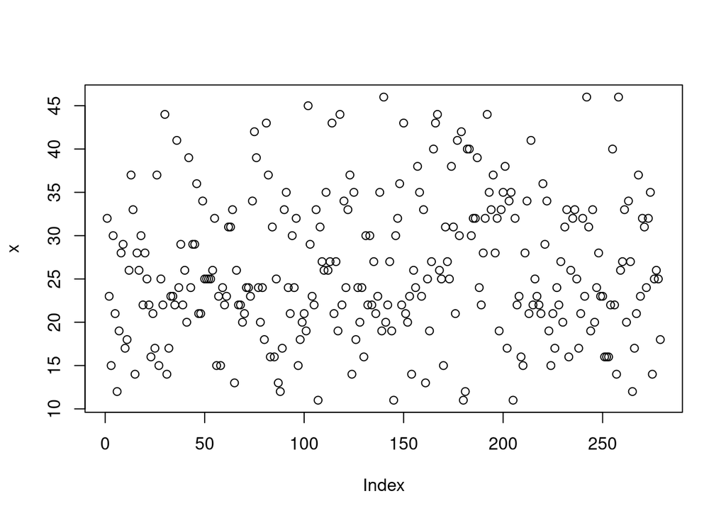

```r
x<-round( rnorm(300, mean=25, sd=9) )
x<-x[x>10]
plot(x)
```

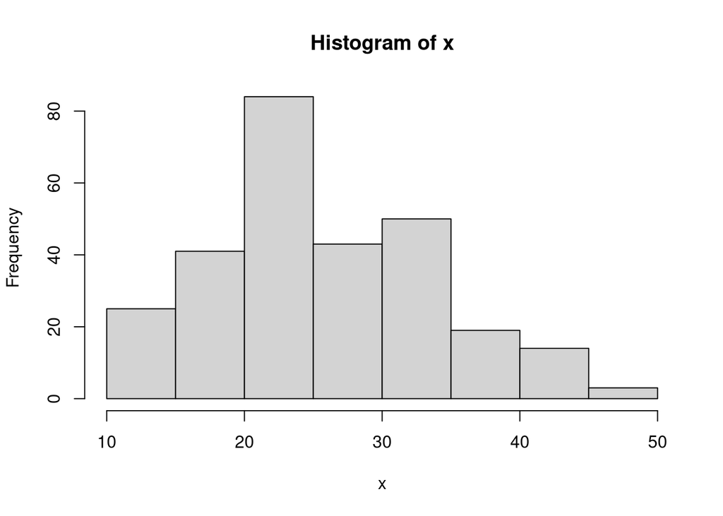

```r
hist(x)
```

```r
str(x)
```

```
##  num [1:279] 32 23 15 30 21 12 19 28 29 17 ...
```

```r
x<-as.data.frame(x)

write.csv(x, file="ages.csv",row.names=F)

#Lee solo la columna x del data.frame
ages<-read.csv("ages.csv")$x
str(ages)
```

```
##  int [1:279] 32 23 15 30 21 12 19 28 29 17 ...
```

```r
#N?mero de personas
length(ages)
```

```
## [1] 279
```

```r
#max,min, mean, median
max(ages)
```

```
## [1] 46
```

```r
min(ages)
```

```
## [1] 11
```

```r
mean(ages)
```

```
## [1] 26.14695
```

```r
median(ages)
```

```
## [1] 25
```

```r
#N?mero de personas por edad
table(ages)
```

```
## ages
## 11 12 13 14 15 16 17 18 19 20 21 22 23 24 25 26 27 28 29 30 31 32 33 34 35 36
##  4  4  3  6  8  9  8  5  9 10 16 21 16 17 14 12 10  7  6  8  9 13 12  7  9  3
## 37 38 39 40 41 42 43 44 45 46
##  6  3  3  4  3  2  4  4  1  3
```

```r
#Fecha nacimiento
birthDate <- 2017 - ages
birthDate
```

```
##   [1] 1985 1994 2002 1987 1996 2005 1998 1989 1988 2000 1999 1991 1980 1984 2003
##  [16] 1989 1991 1987 1995 1989 1992 1995 2001 1996 2000 1980 2002 1992 1995 1973
##  [31] 2003 2000 1994 1994 1995 1976 1993 1988 1995 1991 1997 1978 1993 1988 1988
##  [46] 1981 1996 1996 1983 1992 1992 1992 1992 1991 1985 2002 1994 2002 1993 1995
##  [61] 1994 1986 1986 1984 2004 1991 1995 1995 1997 1996 1993 1993 1994 1983 1975
##  [76] 1978 1993 1997 1993 1999 1974 1980 2001 1986 2001 1992 2004 2005 2000 1984
##  [91] 1982 1993 1996 1987 1993 1985 2002 1999 1997 1996 1998 1972 1988 1994 1995
## [106] 1984 2006 1986 1990 1991 1982 1991 1990 1974 1996 1990 1998 1973 1995 1983
## [121] 1993 1984 1980 2003 1982 1999 1993 1997 1993 2001 1987 1995 1987 1995 1990
## [136] 1996 1994 1982 1998 1971 1997 1995 1990 1998 2006 1987 1985 1981 1995 1974
## [151] 1996 1997 1994 2003 1991 1993 1979 1982 1994 1984 2004 1992 1998 1990 1977
## [166] 1974 1973 1991 1992 2002 1986 1990 1992 1979 1986 1996 1976 1987 1975 2006
## [181] 2005 1977 1977 1987 1985 1985 1978 1993 1995 1989 1985 1973 1982 1984 1980
## [196] 1989 1985 1998 1984 1982 1979 2000 1983 1982 2006 1985 1995 1994 2001 2002
## [211] 1989 1983 1996 1976 1995 1992 1994 1995 1996 1981 1988 1983 1998 2002 1996
## [226] 2000 1993 1995 1990 1997 1986 1984 2001 1991 1985 1984 1992 2000 1996 1985
## [241] 1994 1971 1986 1998 1984 1997 1993 1989 1994 1994 2001 2001 2001 1995 1977
## [256] 1995 2003 1971 1991 1990 1984 1997 1983 1990 2005 2000 1996 1980 1994 1985
## [271] 1986 1993 1985 1982 2003 1992 1991 1992 1999
```

```r
#Personas nacidas entre 1980 y 2000
birthDate[ birthDate >=1980 & birthDate <= 2000 ]
```

```
##   [1] 1985 1994 1987 1996 1998 1989 1988 2000 1999 1991 1980 1984 1989 1991 1987
##  [16] 1995 1989 1992 1995 1996 2000 1980 1992 1995 2000 1994 1994 1995 1993 1988
##  [31] 1995 1991 1997 1993 1988 1988 1981 1996 1996 1983 1992 1992 1992 1992 1991
##  [46] 1985 1994 1993 1995 1994 1986 1986 1984 1991 1995 1995 1997 1996 1993 1993
##  [61] 1994 1983 1993 1997 1993 1999 1980 1986 1992 2000 1984 1982 1993 1996 1987
##  [76] 1993 1985 1999 1997 1996 1998 1988 1994 1995 1984 1986 1990 1991 1982 1991
##  [91] 1990 1996 1990 1998 1995 1983 1993 1984 1980 1982 1999 1993 1997 1993 1987
## [106] 1995 1987 1995 1990 1996 1994 1982 1998 1997 1995 1990 1998 1987 1985 1981
## [121] 1995 1996 1997 1994 1991 1993 1982 1994 1984 1992 1998 1990 1991 1992 1986
## [136] 1990 1992 1986 1996 1987 1987 1985 1985 1993 1995 1989 1985 1982 1984 1980
## [151] 1989 1985 1998 1984 1982 2000 1983 1982 1985 1995 1994 1989 1983 1996 1995
## [166] 1992 1994 1995 1996 1981 1988 1983 1998 1996 2000 1993 1995 1990 1997 1986
## [181] 1984 1991 1985 1984 1992 2000 1996 1985 1994 1986 1998 1984 1997 1993 1989
## [196] 1994 1994 1995 1995 1991 1990 1984 1997 1983 1990 2000 1996 1980 1994 1985
## [211] 1986 1993 1985 1982 1992 1991 1992 1999
```

```r
#Mayores de 30 a?os
#Menores de 20
length( ages[ ages>30 ] )
```

```
## [1] 86
```

```r
length( ages[ ages<20 ] )
```

```
## [1] 56
```

```r
#Conversi?n
ageCategory <- ages
ages<20
```

```
##   [1] FALSE FALSE  TRUE FALSE FALSE  TRUE  TRUE FALSE FALSE  TRUE  TRUE FALSE
##  [13] FALSE FALSE  TRUE FALSE FALSE FALSE FALSE FALSE FALSE FALSE  TRUE FALSE
##  [25]  TRUE FALSE  TRUE FALSE FALSE FALSE  TRUE  TRUE FALSE FALSE FALSE FALSE
##  [37] FALSE FALSE FALSE FALSE FALSE FALSE FALSE FALSE FALSE FALSE FALSE FALSE
##  [49] FALSE FALSE FALSE FALSE FALSE FALSE FALSE  TRUE FALSE  TRUE FALSE FALSE
##  [61] FALSE FALSE FALSE FALSE  TRUE FALSE FALSE FALSE FALSE FALSE FALSE FALSE
##  [73] FALSE FALSE FALSE FALSE FALSE FALSE FALSE  TRUE FALSE FALSE  TRUE FALSE
##  [85]  TRUE FALSE  TRUE  TRUE  TRUE FALSE FALSE FALSE FALSE FALSE FALSE FALSE
##  [97]  TRUE  TRUE FALSE FALSE  TRUE FALSE FALSE FALSE FALSE FALSE  TRUE FALSE
## [109] FALSE FALSE FALSE FALSE FALSE FALSE FALSE FALSE  TRUE FALSE FALSE FALSE
## [121] FALSE FALSE FALSE  TRUE FALSE  TRUE FALSE FALSE FALSE  TRUE FALSE FALSE
## [133] FALSE FALSE FALSE FALSE FALSE FALSE  TRUE FALSE FALSE FALSE FALSE  TRUE
## [145]  TRUE FALSE FALSE FALSE FALSE FALSE FALSE FALSE FALSE  TRUE FALSE FALSE
## [157] FALSE FALSE FALSE FALSE  TRUE FALSE  TRUE FALSE FALSE FALSE FALSE FALSE
## [169] FALSE  TRUE FALSE FALSE FALSE FALSE FALSE FALSE FALSE FALSE FALSE  TRUE
## [181]  TRUE FALSE FALSE FALSE FALSE FALSE FALSE FALSE FALSE FALSE FALSE FALSE
## [193] FALSE FALSE FALSE FALSE FALSE  TRUE FALSE FALSE FALSE  TRUE FALSE FALSE
## [205]  TRUE FALSE FALSE FALSE  TRUE  TRUE FALSE FALSE FALSE FALSE FALSE FALSE
## [217] FALSE FALSE FALSE FALSE FALSE FALSE  TRUE  TRUE FALSE  TRUE FALSE FALSE
## [229] FALSE FALSE FALSE FALSE  TRUE FALSE FALSE FALSE FALSE  TRUE FALSE FALSE
## [241] FALSE FALSE FALSE  TRUE FALSE FALSE FALSE FALSE FALSE FALSE  TRUE  TRUE
## [253]  TRUE FALSE FALSE FALSE  TRUE FALSE FALSE FALSE FALSE FALSE FALSE FALSE
## [265]  TRUE  TRUE FALSE FALSE FALSE FALSE FALSE FALSE FALSE FALSE  TRUE FALSE
## [277] FALSE FALSE  TRUE
```

```r
ageCategory[ ages<20 ] <- "VY"
ageCategory[ ages>=20 & ages<35] <-"Y"
ageCategory[ ages>=35 & ages<50] <-"A"
ageCategory[ ages>=50 & ages<65] <-"OA"
ageCategory[ ages>=65 ] <-"O"
ageCategory
```

```
##   [1] "Y"  "Y"  "VY" "Y"  "Y"  "VY" "VY" "Y"  "Y"  "VY" "VY" "Y"  "A"  "Y"  "VY"
##  [16] "Y"  "Y"  "Y"  "Y"  "Y"  "Y"  "Y"  "VY" "Y"  "VY" "A"  "VY" "Y"  "Y"  "A"
##  [31] "VY" "VY" "Y"  "Y"  "Y"  "A"  "Y"  "Y"  "Y"  "Y"  "Y"  "A"  "Y"  "Y"  "Y"
##  [46] "A"  "Y"  "Y"  "Y"  "Y"  "Y"  "Y"  "Y"  "Y"  "Y"  "VY" "Y"  "VY" "Y"  "Y"
##  [61] "Y"  "Y"  "Y"  "Y"  "VY" "Y"  "Y"  "Y"  "Y"  "Y"  "Y"  "Y"  "Y"  "Y"  "A"
##  [76] "A"  "Y"  "Y"  "Y"  "VY" "A"  "A"  "VY" "Y"  "VY" "Y"  "VY" "VY" "VY" "Y"
##  [91] "A"  "Y"  "Y"  "Y"  "Y"  "Y"  "VY" "VY" "Y"  "Y"  "VY" "A"  "Y"  "Y"  "Y"
## [106] "Y"  "VY" "Y"  "Y"  "Y"  "A"  "Y"  "Y"  "A"  "Y"  "Y"  "VY" "A"  "Y"  "Y"
## [121] "Y"  "Y"  "A"  "VY" "A"  "VY" "Y"  "Y"  "Y"  "VY" "Y"  "Y"  "Y"  "Y"  "Y"
## [136] "Y"  "Y"  "A"  "VY" "A"  "Y"  "Y"  "Y"  "VY" "VY" "Y"  "Y"  "A"  "Y"  "A"
## [151] "Y"  "Y"  "Y"  "VY" "Y"  "Y"  "A"  "A"  "Y"  "Y"  "VY" "Y"  "VY" "Y"  "A"
## [166] "A"  "A"  "Y"  "Y"  "VY" "Y"  "Y"  "Y"  "A"  "Y"  "Y"  "A"  "Y"  "A"  "VY"
## [181] "VY" "A"  "A"  "Y"  "Y"  "Y"  "A"  "Y"  "Y"  "Y"  "Y"  "A"  "A"  "Y"  "A"
## [196] "Y"  "Y"  "VY" "Y"  "A"  "A"  "VY" "Y"  "A"  "VY" "Y"  "Y"  "Y"  "VY" "VY"
## [211] "Y"  "Y"  "Y"  "A"  "Y"  "Y"  "Y"  "Y"  "Y"  "A"  "Y"  "Y"  "VY" "VY" "Y"
## [226] "VY" "Y"  "Y"  "Y"  "Y"  "Y"  "Y"  "VY" "Y"  "Y"  "Y"  "Y"  "VY" "Y"  "Y"
## [241] "Y"  "A"  "Y"  "VY" "Y"  "Y"  "Y"  "Y"  "Y"  "Y"  "VY" "VY" "VY" "Y"  "A"
## [256] "Y"  "VY" "A"  "Y"  "Y"  "Y"  "Y"  "Y"  "Y"  "VY" "VY" "Y"  "A"  "Y"  "Y"
## [271] "Y"  "Y"  "Y"  "A"  "VY" "Y"  "Y"  "Y"  "VY"
```

```r
str(ageCategory)
```

```
##  chr [1:279] "Y" "Y" "VY" "Y" "Y" "VY" "VY" "Y" "Y" "VY" "VY" "Y" "A" "Y" ...
```

```r
#Cuantas personas de cada categor?a de edad
table(ageCategory)
```

```
## ageCategory
##   A  VY   Y
##  45  56 178
```